# EDA buscas

Aline Costa

O objeto principal da análise são as buscas e a navegação depois da busca. Criamos esses dados a partir dos dados originais da wikimedia em `/data/search_data.csv`.

Aqui, exploramos esses dados.

```r
library(tidyverse)
library(here)
library(lubridate)
theme_set(theme_bw())
```

```r
buscas = read_csv(here::here("data/search_data.csv"))
```

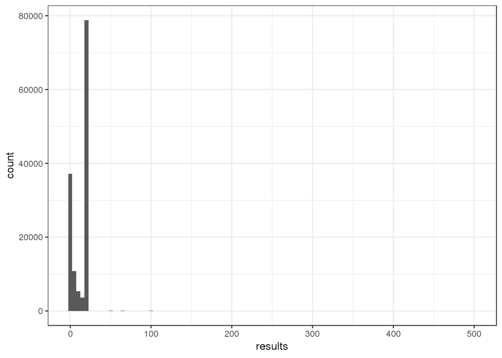

```r
buscas %>%
    ggplot(aes(x = results)) +
    geom_histogram(binwidth = 5)
```

### Passando os dias, como a média vai evoluindo? Depois add os grupos.

Criando uma coluna de data, derivada da coluna session_start_date.

```r
buscas_com_data <- buscas %>%
    mutate(data = format(session_start_date, "%Y-%m-%d"))
```

Para analisar a variação de cliques ao longo dos dias, vamos considerar que a média de cliques é a média geral de cliques em cada dia.

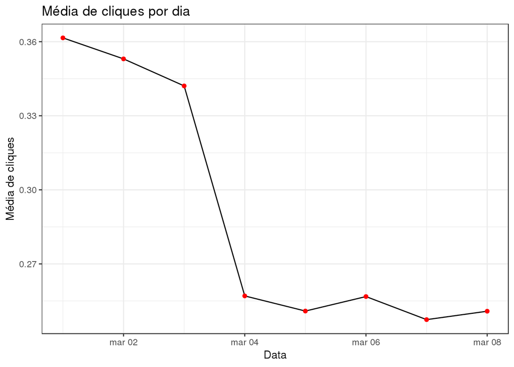

```r
media <- buscas_com_data %>%
  group_by(data) %>%
  summarise(media_click = mean(num_clicks))

media %>%
    ggplot(aes(x = as.Date(data), y = media_click)) +
    geom_line() +
    labs(
        y = "Média de cliques",
        x = "Data",
        title = "Média de cliques por dia") +
    geom_point(color = "red")
```

Observando a visualização acima pordemos ver que, de modo geral, a média de cliques é maior nos primeiros dias e sempre menor que 1. Isso pode ser explicado pelo grande número de pesquisas onde o usuário não clica em nenhum resultado.

Vamos ver se essa observação se mantém analisando os grupos ‘a’ e ‘b’ separadamente:

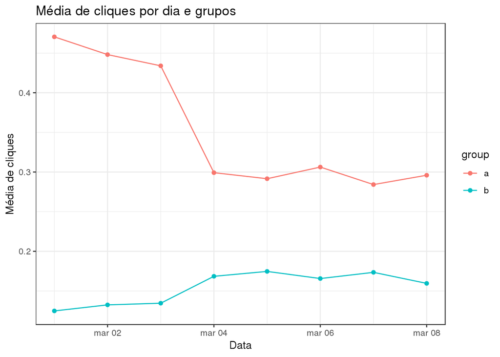

```r
media <- buscas_com_data %>%
  group_by(data, group) %>%
  summarise(media_click = mean(num_clicks)) # ajustar para mostrar todas as datas


media %>%
    ggplot(aes(x = as.Date(data), y = media_click, color = group)) +
    geom_line() +
    labs(
        y = "Média de cliques",
        x = "Data",
        title = "Média de cliques por dia e grupos") +
    geom_point()
```

A média de cliques se mantém menor que 1 considerando os grupos separadamente, no entanto, é mais fácil notar alguma diferença entre eles. Para o grupo ‘a’, a média de cliques é mais alta que as média para o grupo ‘b’, considerando nossos dados.

Vamos ver a mesma visualização acima mas sem considerar as sessões onde não houve nenhum clique.

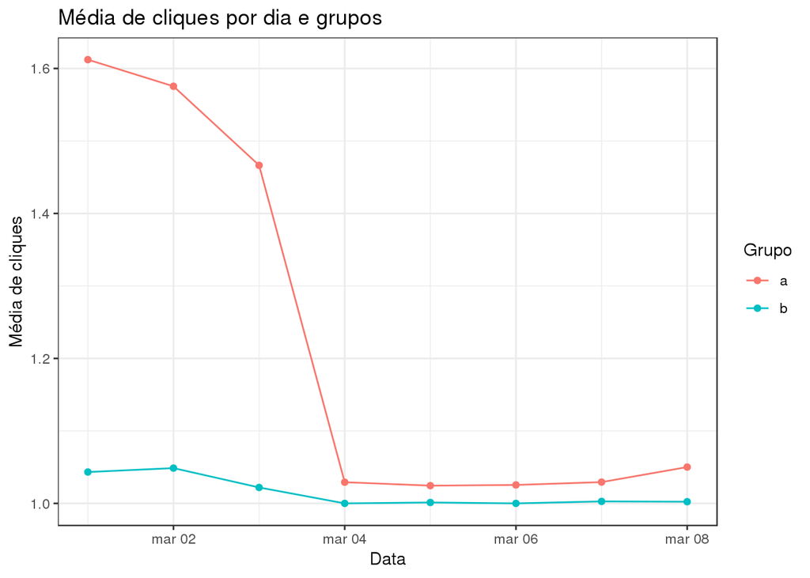

```r
media_com_cliques <- buscas_com_data %>%
  filter(num_clicks != 0) %>%
  group_by(data, group) %>%
  summarise(media_click = mean(num_clicks)) # ajustar para mostrar todas as datas


media_com_cliques %>%
    ggplot(aes(x = as.Date(data), y = media_click, color = group)) +
    geom_line() +
    labs(
        y = "Média de cliques",
        x = "Data",
        title = "Média de cliques por dia e grupos", color = "Grupo") +
    geom_point()
```

Agora podemos ver mais claramente uma grande diferença na média de cliques para os grupos a e b nos dias 1, 2, e 3 de março.

### Quais resultados as pessoas tendem a tentar primeiro? Como isso muda no dia-a-dia?

Vamos ver a classificação geral para os 16 resultados mais clicados. Ressaltando que não vamos considerar os casos onde não houve clique em nenhum link.

```r
busca_com_contagem_cliques <- buscas %>%
  group_by(first_click) %>%
  summarise(count_click = n()) %>%
    arrange(desc(count_click)) %>%
    top_n(16)
```

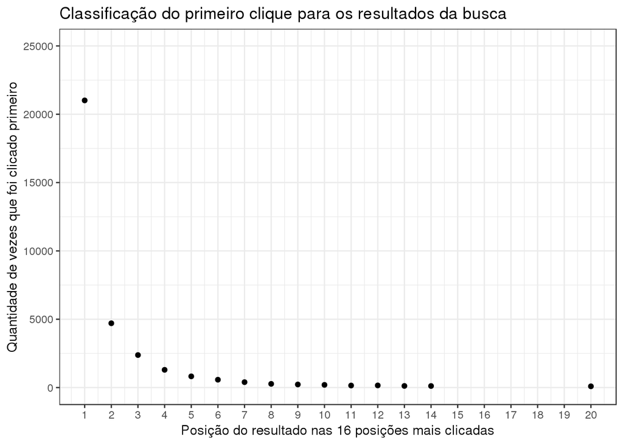

```r
busca_com_contagem_cliques %>%
    filter (first_click != "NA") %>%
    ggplot(aes(x = first_click, y = count_click)) +
    geom_point() +
    scale_y_continuous(limits=c(0, 25000)) +
    scale_x_continuous(breaks=seq(1, 20, 1)) +
    labs(
        y = "Quantidade de vezes que foi clicado primeiro",
        x = "Posição do resultado nas 16 posições mais clicadas",
        title = "Classificação do primeiro clique para os resultados da busca")
```

Pelo gráfico acima podemos ver que os resultados que as pessoas tendem a clicar primeiro são os links exibidos primeiros. Mais especificamente, a sequência de resultados mais acessados é igual para os 10 primeiros resultados. Depois varia um pouco. Os links 15, 16, 17, 18 e 19 não aparecem entre os 16 mais clicados.

Para analisar se a distribuição dos cliques muda ao longo dos dias vamos adicionar os dias da semana.

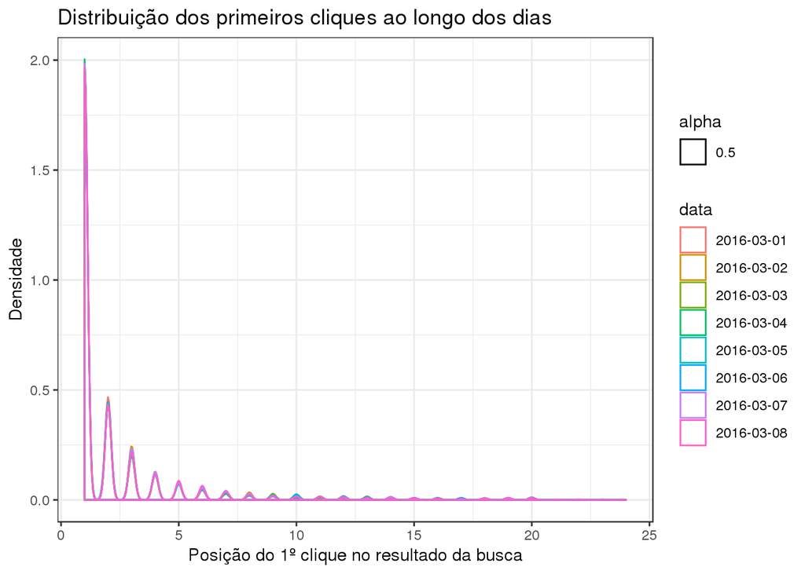

```r
buscas_com_data %>%
    filter (first_click < 25) %>%
    ggplot(aes(color = data, x = first_click, alpha=0.5)) +
    geom_density() +
    labs(
        y = "Densidade",
        x = "Posição do 1º clique no resultado da busca",
        title = "Distribuição dos primeiros cliques ao longo dos dias ")
```

Com uma visualização que sobrepõe a distribuição para os dias da semana não conseguimos distriguir variação significante nos primeiros links clicados (limitados aos 25 primeiros) ao longo dos dias. Isso indica que a distribuição geral segue da mesma forma para os dias. Vamos visualizar os dias em gráficos separados…

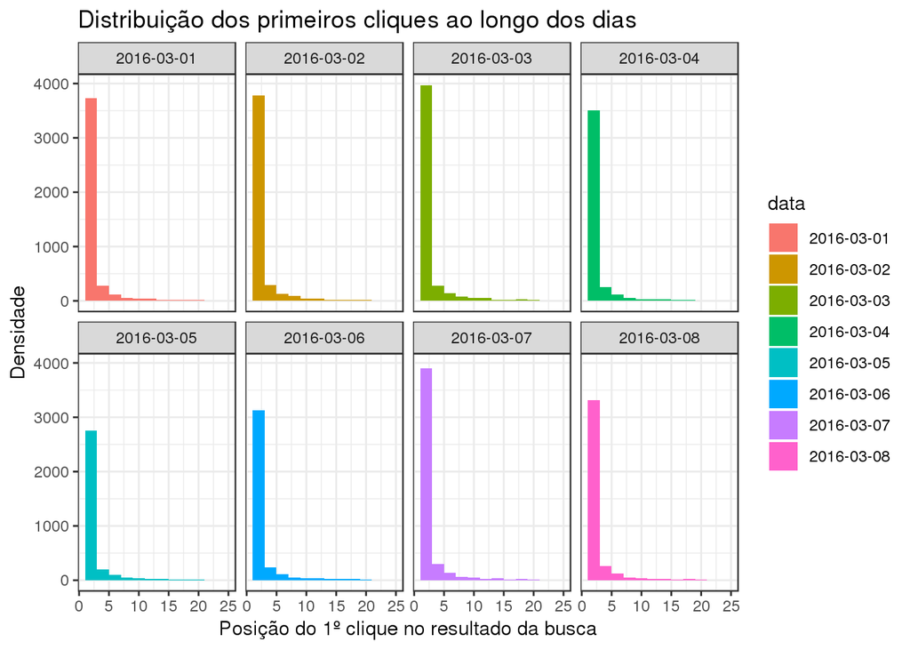

```r
buscas_com_data %>%
    filter (first_click < 25) %>%
    ggplot(aes(x = first_click, fill = data)) +
    geom_histogram(binwidth = 2, na.rm = TRUE) +
    facet_wrap(~ data, nrow=2) +
    labs(
        y = "Densidade",
        x = "Posição do 1º clique no resultado da busca",
        title = "Distribuição dos primeiros cliques ao longo dos dias ")
```

Podemos ver que ainda assim não é possível distinguir variações claras. A distribuição de cliques segue praticamente o mesmo formato ao longo dos dias, se concentrando nos 5 primeiros resultados da busca. O que podemos identificar apenas são algumas poucas diferenças nas caldas das distribuições e que no dia 05 aparentemente foram realizadas menos buscas.

Como os resultados mais clicados se concentram sempre nos 5 primeiros, vamos ver quantos registros clicam primeiro em um link de posição maior que 5.

```r
nrow(buscas_com_data %>% filter(first_click > 5))
```

```
## [1] 2980
```

```r
nrow(buscas_com_data)
```

```
## [1] 136234
```

Temos, portanto, 2.980 resultados onde o primeiro clique foi dado em um link maior que 5. Isso significa aproximadamente 2.19% dos 136234 registros analisados. Lembrando que em muitos dos 136234 não houve clique em nenhum link.

Como mostrado abaixo, essa quantidade de cliques em links maiores que o quinto varia com os dias.

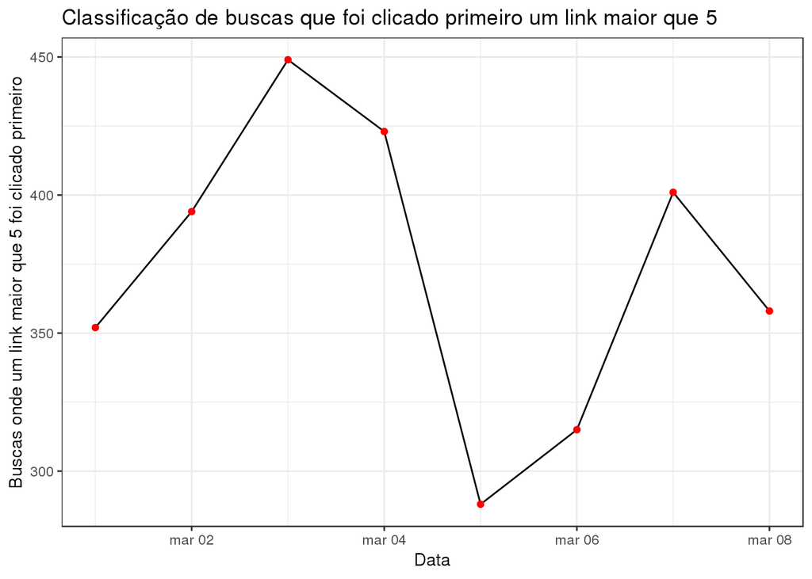

```r
busca_com_contagem_cliques_maior_que_5 <- buscas_com_data %>%
  filter(first_click > 5) %>%
  group_by(data) %>%
  summarise(count_click = n())

busca_com_contagem_cliques_maior_que_5 %>%
    ggplot(aes(x = as.Date(data), y = count_click)) +
    geom_line() +
    labs(
        y = "Buscas onde um link maior que 5 foi clicado primeiro",
        x = "Data",
        title = "Classificação de buscas que foi clicado primeiro um link maior que 5") +
    geom_point(color = "red")
```

### Qual é a nossa taxa de resultados zero no geral? Como isso varia entre os grupos?

Vamos ver a distribuição de resultados zero ao longo dos dias.

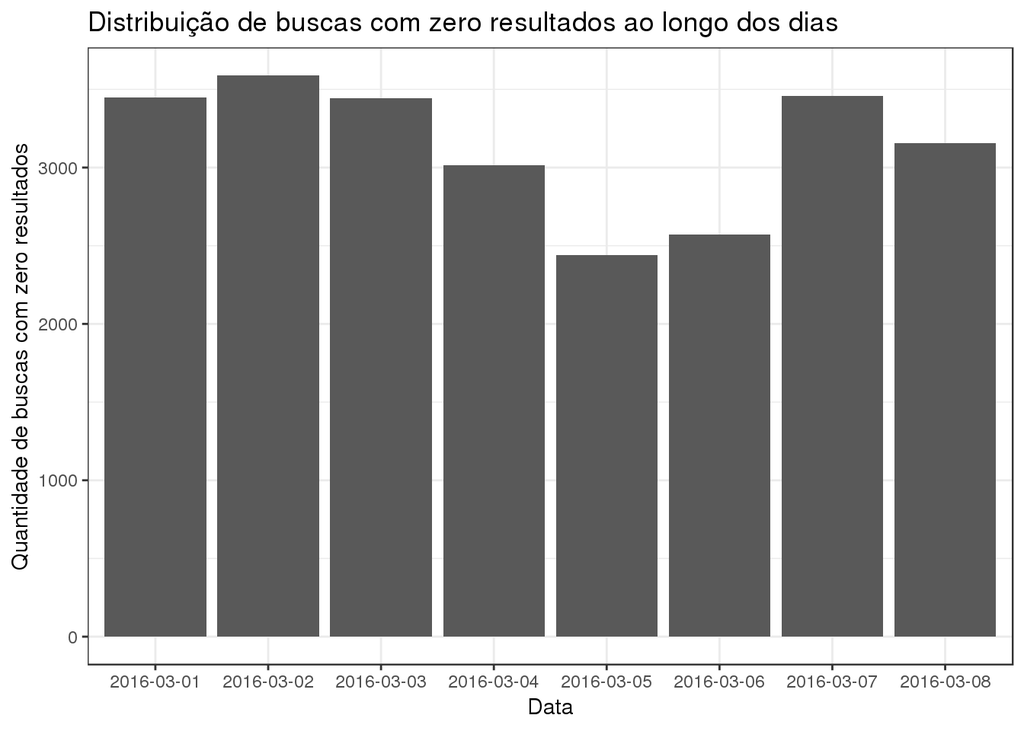

```r
buscas_com_data %>%
    filter(results == 0) %>%
    ggplot(aes(x = data)) +
    geom_bar() +
    labs(
        y = "Quantidade de buscas com zero resultados",
        x = "Data",
        title = "Distribuição de buscas com zero resultados ao longo dos dias ")
```

Para visualizar melhor a proporção de resultados zero ao longo dos dias vamos adicionar também a quantidade total de buscas realizadas.

Criando a coluna de é busca “eh_zero”

```r
buscas_com_results_zero <- buscas_com_data %>%
    mutate(eh_resultado_zero = results == 0)
```

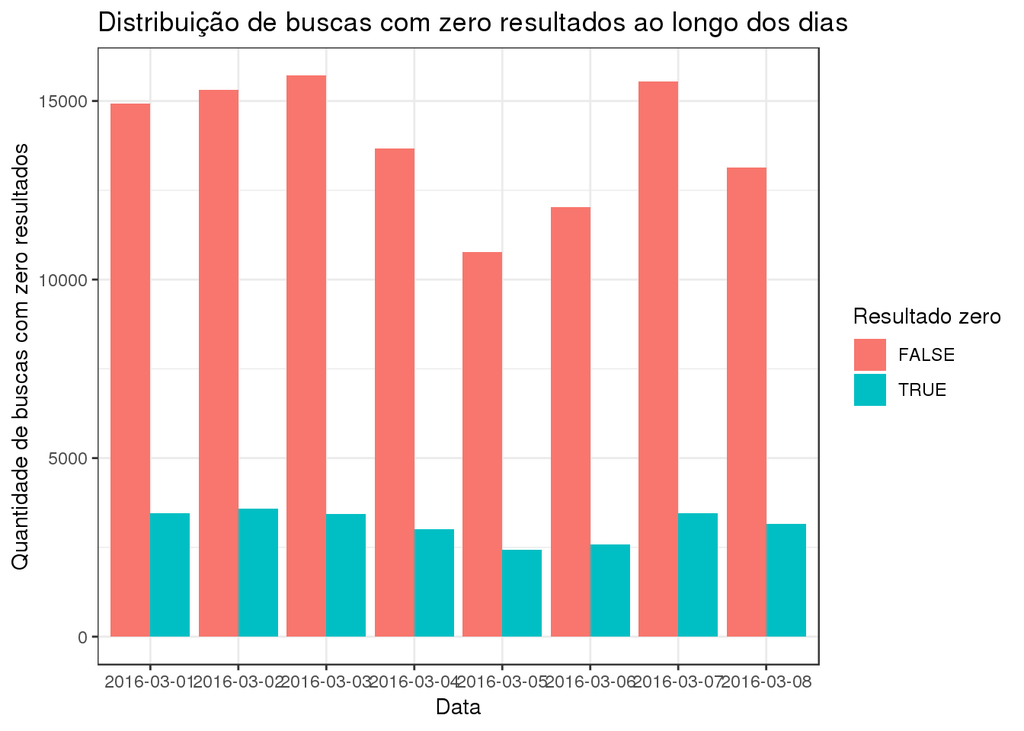

```r
buscas_com_results_zero %>%
    filter(!is.na(results) & !is.na(data)) %>%
    ggplot(aes(data, fill=eh_resultado_zero)) +
    geom_bar(position=position_dodge()) +
    labs(
        y = "Quantidade de buscas com zero resultados",
        x = "Data",
        title = "Distribuição de buscas com zero resultados ao longo dos dias ", fill="Resultado zero")
```

No geral, a quantidade de resultados zero retornados por cada grupo.

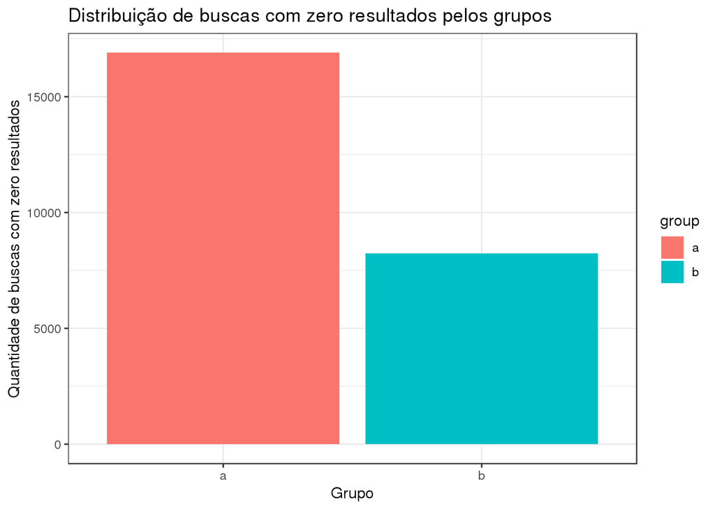

```r
buscas_com_data %>%
    filter(!is.na(results) & results == 0) %>%
    ggplot(aes(x = group, fill=group)) +
    geom_bar() +
    labs(
        y = "Quantidade de buscas com zero resultados",
        x = "Grupo",
        title = "Distribuição de buscas com zero resultados pelos grupos ")
```

Vemos que o grupo de buscas com o Algoritmo ‘a’ retorna uma maior quantidade de buscas com zero resultados.

### A duração da sessão é aproximadamente o tempo entre o primeiro e o último evento de uma sessão. Escolha uma variável do conjunto de dados e descreva sua relação com o tamanho da sessão. Visualize o relacionamento.

Vamos estudar a relação entre quantidade de cliques e o tamanho de cada sessão, onde a duração da sessão é aproximadamente o tempo entre o primeiro e o último evento de uma sessão. Vamos considerar como suposição inicial de que as sessões maiores apresentam uma maior quantidade de cliques.

Vamos inicialmente ver a distribuição dos dados para as variáveis session_length e num_clicks. Para uma análise mais precisa, vamos desconsiderar os registros de session_length zero.

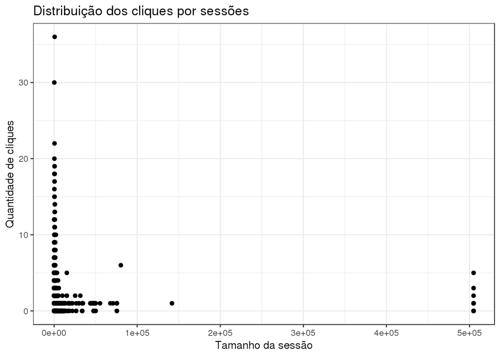

```r
buscas_com_data %>%
    filter (session_length != 0) %>%
    ggplot(aes(x = session_length, y = num_clicks)) +
    geom_point()  +
    labs(
        y = "Quantidade de cliques",
        x = "Tamanho da sessão",
        title = "Distribuição dos cliques por sessões")
```

A primeira impressão observando o gráfico acima é que o tamanho da sessão não teria muita influência na quantidade de cliques. Então nossa suposição inicial não se mostra válida. A maior quantidade de cliques parace se concentrar em sessões menores.

No entanto, podemos ver que os dados são muito concentrados a esquerda e abaixo, tornando difícil fazer qualquer observação sobre a correlação. Para melhorar a análise, vamos aplicando o log de base 10 nos diferentes grupos. Assim, a medida da correlação não será tão influenciada pelos outliers.

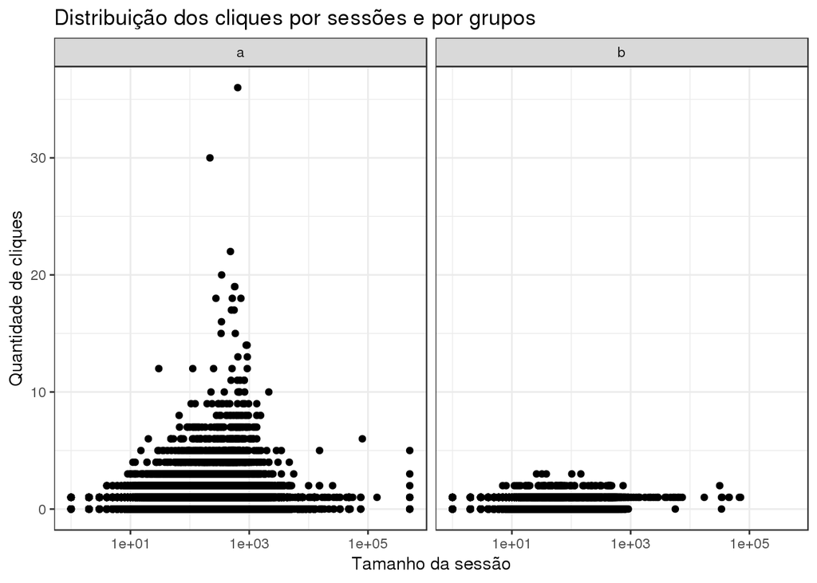

```r
buscas_com_data %>%
    filter (session_length != 0) %>%
    ggplot(aes(x = session_length, y = num_clicks)) +
    geom_point() +
    scale_x_continuous(trans = 'log10') +
    facet_wrap(~ group)  +
    labs(
        y = "Quantidade de cliques",
        x = "Tamanho da sessão",
        title = "Distribuição dos cliques por sessões e por grupos")
```

A análise não parece indicar que existe uma correlação entre a quantidade de cliques e o tamanho de cada sessão. Para confirmar nossa intuição vemos abaixo os valores sumarizados pelos métodos de correlação pearson, spearman e kendall. Os valores indicam uma baixa correlação entre as variáveis. 0.01 para pearson, 0.25 para spearman e kendall 0.21.

```r
buscas_com_data %>%
    summarise(
    pearson = cor(session_length, num_clicks, method = "pearson"),
    spearman = cor(session_length, num_clicks, method = "spearman"),
    kendall = cor(session_length, num_clicks, method = "kendall")
  )
```

| pearson | spearman | kendall |
| --- | --- | --- |
| 0.01881768 | 0.2560916 | 0.2106593 |

Entre os grupo a correlação é um pouco diferente. A correlação é maior para o grupo ‘b’, como pode ser visto abaixo. Para o grupo ‘a’ a correlação varia entre 0.008 e 0.06 e para o grupo ‘b’ fica entre 0.1 e 0.6

Para o grupo ‘a’

```r
buscas_com_data %>%
    filter(group == 'a') %>%
    summarise(
    pearson = cor(session_length, num_clicks, method = "pearson"),
    spearman = cor(session_length, num_clicks, method = "spearman"),
    kendall = cor(session_length, num_clicks, method = "kendall")
  )
```

| pearson | spearman | kendall |
| --- | --- | --- |
| 0.008283491 | 0.0681847 | 0.05467785 |

Para o grupo ‘b’

```r
buscas_com_data %>%
    filter(group == 'b') %>%
    summarise(
    pearson = cor(session_length, num_clicks, method = "pearson"),
    spearman = cor(session_length, num_clicks, method = "spearman"),
    kendall = cor(session_length, num_clicks, method = "kendall")
  )
```

| pearson | spearman | kendall |
| --- | --- | --- |
| 0.1241773 | 0.6026073 | 0.5480458 |